# An Analysis of the Age of Contestants and Viewership of the Great British Baking Show

### 2023 - 03 - 06

# Introduction

The Great British Bake Off is an internationally beloved British baking show, consisting of several competitions between amateur bakers. Each season, or series as they are referred to by the British, begins with 12 bakers, with one being eliminated from the show by the judges after every episode for the ten episodes. The judges are Paul Hollywood, who is trained in both sculpting and baking, allowing him to become a pioneer in the baking field, and Prue Leith, the founder of a culinary school that has produced multiple other famous chefs. The show is hosted by two comedians and actors, Noel Fielding and Matt Lucas. The first series of the show aired in 2010, and in my analysis, I will explore the first ten series, spanning from 2010 to 2019, but the show has had several seasons since. The Great British Bake Off has become not only popular in its home country of the United Kingdom but all over the world; possibly because of its comforting nature. The bakers compete outdoors, in a tent, surrounded by a field of flowers, and while they are in a stress filled competition consisting of 3 different challenges (the Signature Bake, the Technical Challenge, and the Showstopper Bake), there is a sense of coziness that the show brings to viewers.

In this analysis, I used a data set called “Great British Bakeoff,” which contains information about the challenges, bakers, ratings, and episodes, in addition to more detailed information when these topics are broken down. In my analysis, I use the data set called “bakers,” which contains information about the series number each baker appeared, their name, the number of time they’ve one each challenge, their age, etc. and the data set called “ratings” which contains the viewership information for each episode of each series of the show. The analysis I wish to conduct is a review of the correlation between the average age of the contestants on the show and its viewership ratings.

# Packages

```r
library(ggplot2)
library(grid)
library(gridExtra)
library(tidyverse)
library(bakeoff)
bakers <- readr::read_csv('https://raw.githubusercontent.com/rfordatascience/tidytuesday/master/data/2022/2022-10-25/bakers.csv')
```

# Data Preparation

The data set was obtained from the following link: https://github.com/rfordatascience/tidytuesday/tree/master/data/2022/2022-10-25#great-british-bakeoff. This data was obtained by Alison Hill, Chester Ismay, and Richard Iannone. Even though it is not outright stated, it seems that those who collected the data acquired it by watching the first ten seasons of the Great British Bake Off and tracking all of the information themselves that they could, it is not stated where the ratings information came from but it can be assumed that it came from the network on which the show airs, BBC. The original “bakers” data set included the variables:

- series - a double representing the season/series number
- bakers - a character representing the baker’s name)
- star_baker - an integer representing how many times the baker was named star baker
- technical_winner - an integer representing how many times the baker won the technical challenge
- technical_top3 - an integer representing how many times the baker ranked in the top 3 of the technical challenge
- technical_bottom - an integer representing how many times the baker was ranked in the bottom of the technical challenge
- technical_highest - a double representing how many times the baker was ranked highest in the technical challenge
- technical_lowest - a double representing how many times the baker was ranked lowest in the technical challenge
- technical_median - a double representing how many times the baker was ranked as the median in the technical challenge
- series_winner - an integer representing how many times the baker was named the winner of the series
- series_runner_up - an integer representing how many times the baker was named the runner up of the series
- total_episodes_appeared - a double representing the total number of episodes on which the baker appeared
- first_date_appeared - a double representing the date of the episode on which the baker first appeared
- last_date_appeared - a double representing the date of the episode on which the baker last appeared
- first_date_us - a double representing the date of the episode on which the baker first appeared when aired in the United States
- last_date_us - a double representing the date of the episode on which the baker last appeared when aired in the United States
- percent_episodes_appeared - a double representing the percentage of episodes that the baker appeared in
- percent_technical_top3- a double representing the percent of the challenges in which the baker was in the top 3 of the technical challenge
- baker_full - a character representing the baker’s full name
- age - a double representing the baker’s age
- occupation - a character representing the baker’s occupation
- hometown - a character representing the baker’s hometown
- baker_last - a character representing the baker’s last name
- baker_first - a character representing the baker’s first name The original “ratings” data set included the variables:
- series - a double representing the season/series number
- episode - a double representing the episode number
- uk_airdate - a double representing the date that the episode aired in the United Kingdom
- viewers_7day - a double representing the number of viewers over a 7 day period (in millions)
- viewers_28day - a double representing the number of viewers over a 28 day period (in millions)
- network_rank - a double representing the rank of the episode given by the network
- channels_rank - a double representing the rank of the episode given by the channel
- bb_iplayer_requests - double representing the amount of BBC iPlayer (a British streaming service) requests
- episode_count - a double representing the episode count
- us_season - a double representing the number of the season in the United States
- us_airdate - a character representing the date that the episode aired in the United States

The following code represents the original data, giving preliminary information about the show:

```r
summary(bakers)
```

```
##      series        baker             star_baker technical_winner
##  Min.   : 1.0   Length:120         Min.   :0    Min.   :0.000
##  1st Qu.: 3.0   Class :character   1st Qu.:0    1st Qu.:0.000
##  Median : 6.0   Mode  :character   Median :0    Median :0.000
##  Mean   : 5.6                      Mean   :0    Mean   :0.775
##  3rd Qu.: 8.0                      3rd Qu.:0    3rd Qu.:1.000
##  Max.   :10.0                      Max.   :0    Max.   :5.000
##
##  technical_top3  technical_bottom technical_highest technical_lowest
##  Min.   :0.000   Min.   :0.000    Min.   : 1.000    Min.   : 4.000
##  1st Qu.:0.000   1st Qu.:2.000    1st Qu.: 1.000    1st Qu.: 7.000
##  Median :2.000   Median :3.000    Median : 2.000    Median : 9.000
##  Mean   :2.325   Mean   :3.475    Mean   : 3.261    Mean   : 8.916
##  3rd Qu.:4.000   3rd Qu.:5.000    3rd Qu.: 4.500    3rd Qu.:10.500
##  Max.   :8.000   Max.   :7.000    Max.   :13.000    Max.   :13.000
##                                   NA's   :1         NA's   :1
##  technical_median series_winner     series_runner_up total_episodes_appeared
##  Min.   : 1.500   Min.   :0.00000   Min.   :0        Min.   : 1.000
##  1st Qu.: 3.500   1st Qu.:0.00000   1st Qu.:0        1st Qu.: 3.000
##  Median : 5.000   Median :0.00000   Median :0        Median : 6.000
##  Mean   : 5.639   Mean   :0.08333   Mean   :0        Mean   : 5.917
##  3rd Qu.: 7.000   3rd Qu.:0.00000   3rd Qu.:0        3rd Qu.: 9.000
##  Max.   :13.000   Max.   :1.00000   Max.   :0        Max.   :10.000
##  NA's   :1
##  first_date_appeared  last_date_appeared   first_date_us  last_date_us
##  Min.   :2010-08-17   Min.   :2010-08-17   Mode:logical   Mode:logical
##  1st Qu.:2012-08-14   1st Qu.:2012-08-24   NA's:120       NA's:120
##  Median :2014-08-06   Median :2014-08-06
##  Mean   :2014-03-11   Mean   :2014-04-14
##  3rd Qu.:2016-02-13   3rd Qu.:2016-03-16
##  Max.   :2017-08-29   Max.   :2017-10-31
##  NA's   :25           NA's   :25
##  percent_episodes_appeared percent_technical_top3  baker_full
##  Min.   : 10.00            Min.   : 0.00          Length:120
##  1st Qu.: 33.33            1st Qu.: 0.00          Class :character
##  Median : 64.58            Median :33.33          Mode  :character
##  Mean   : 62.42            Mean   :30.46
##  3rd Qu.:100.00            3rd Qu.:50.00
##  Max.   :100.00            Max.   :80.00
##
##       age         occupation          hometown          baker_last
##  Min.   :17.00   Length:120         Length:120         Length:120
##  1st Qu.:28.75   Class :character   Class :character   Class :character
##  Median :34.00   Mode  :character   Mode  :character   Mode  :character
##  Mean   :37.39
##  3rd Qu.:45.00
##  Max.   :71.00
##
##  baker_first
##  Length:120
##  Class :character
##  Mode  :character
##
##
##
##
```

```r
head(bakers)
```

```
## # A tibble: 6 × 24
##   series baker   star_…¹ techn…² techn…³ techn…⁴ techn…⁵ techn…⁶ techn…⁷ serie…⁸
##    <dbl> <chr>     <dbl>   <dbl>   <dbl>   <dbl>   <dbl>   <dbl>   <dbl>   <dbl>
## 1      1 Annetha       0       0       1       1       2       7     4.5       0
## 2      1 David         0       0       1       3       3       8     4.5       0
## 3      1 Edd           0       2       4       1       1       6     2         1
## 4      1 Jasmin…       0       0       2       2       2       5     3         0
## 5      1 Jonath…       0       1       1       2       1       9     6         0
## 6      1 Lea           0       0       0       1      10      10    10         0
## # … with 14 more variables: series_runner_up <dbl>,
## #   total_episodes_appeared <dbl>, first_date_appeared <date>,
## #   last_date_appeared <date>, first_date_us <lgl>, last_date_us <lgl>,
## #   percent_episodes_appeared <dbl>, percent_technical_top3 <dbl>,
## #   baker_full <chr>, age <dbl>, occupation <chr>, hometown <chr>,
## #   baker_last <chr>, baker_first <chr>, and abbreviated variable names
## #   ¹star_baker, ²technical_winner, ³technical_top3, ⁴technical_bottom, …
```

```r
summary(ratings)
```

```
##      series          episode         uk_airdate          viewers_7day
##  Min.   : 1.000   Min.   : 1.000   Min.   :2010-08-17   Min.   : 2.240
##  1st Qu.: 3.250   1st Qu.: 3.000   1st Qu.:2013-01-01   1st Qu.: 6.612
##  Median : 6.000   Median : 5.000   Median :2015-08-22   Median : 8.970
##  Mean   : 5.766   Mean   : 5.287   Mean   :2015-06-24   Mean   : 8.580
##  3rd Qu.: 8.000   3rd Qu.: 8.000   3rd Qu.:2017-10-08   3rd Qu.:10.273
##  Max.   :10.000   Max.   :10.000   Max.   :2019-10-29   Max.   :15.900
##
##  viewers_28day     network_rank    channels_rank  bbc_iplayer_requests
##  Min.   : 1.000   Min.   : 1.000   Min.   :1.00   Min.   :1370000
##  1st Qu.: 1.000   1st Qu.: 1.000   1st Qu.:1.00   1st Qu.:1715750
##  Median : 8.980   Median : 1.000   Median :2.00   Median :1915500
##  Mean   : 6.412   Mean   : 2.871   Mean   :2.02   Mean   :1862700
##  3rd Qu.: 9.930   3rd Qu.: 1.000   3rd Qu.:3.00   3rd Qu.:1985250
##  Max.   :16.030   Max.   :18.000   Max.   :4.00   Max.   :2314000
##  NA's   :1        NA's   :24       NA's   :44     NA's   :74
##  episode_count     us_season   us_airdate
##  Min.   : 1.00   Min.   :1    Length:94
##  1st Qu.:24.25   1st Qu.:2    Class :character
##  Median :47.50   Median :3    Mode  :character
##  Mean   :47.50   Mean   :3
##  3rd Qu.:70.75   3rd Qu.:4
##  Max.   :94.00   Max.   :5
##                  NA's   :44
```

```r
head(ratings)
```

```
## # A tibble: 6 × 11
##   series episode uk_airdate viewers_7day viewe…¹ netwo…² chann…³ bbc_i…⁴ episo…⁵
##    <dbl>   <dbl> <date>            <dbl>   <dbl>   <dbl>   <dbl>   <dbl>   <dbl>
## 1      1       1 2010-08-17         2.24       7      NA      NA      NA       1
## 2      1       2 2010-08-24         3          3      NA      NA      NA       2
## 3      1       3 2010-08-31         3          2      NA      NA      NA       3
## 4      1       4 2010-09-07         2.6        4      NA      NA      NA       4
## 5      1       5 2010-09-14         3.03       1      NA      NA      NA       5
## 6      1       6 2010-09-21         2.75       1      NA      NA      NA       6
## # … with 2 more variables: us_season <dbl>, us_airdate <chr>, and abbreviated
## #   variable names ¹viewers_28day, ²network_rank, ³channels_rank,
## #   ⁴bbc_iplayer_requests, ⁵episode_count
```

In order to begin my analysis, I had to tidy the data and create new variables that had only the data that was necessary for my exploration. First, I wanted to get the average age of the bakers in each season. To do this, I made the data set “bakers” into a tibble, then used the select( ) function in order to make the new “bakers” tibble only have the data for series and the ages. I then used the aggregate( ) function to get the mean age of the bakers of the same series and replace that as the tibble called bakers, I finally changed the column names to appropriately represent the variables, and used the head( ) function to check my work.

```r
bakers <- as_tibble(bakers)

bakers <- bakers %>%
  select(series, age)

bakers <- aggregate(bakers$age, list(bakers$series), mean)
colnames(bakers)[1] <- "series"
colnames(bakers)[2] <- "average age"
head(bakers)
```

```
##   series average age
## 1      1    36.60000
## 2      2    36.66667
## 3      3    35.50000
## 4      4    38.53846
## 5      5    41.75000
## 6      6    39.75000
```

I followed a similar process with the ratings data set, keeping only the releavant columns and taking their average for each series.

```r
ratings <- as_tibble(ratings)
ratings <- ratings %>%
  select(series, viewers_7day, viewers_28day, network_rank)

ratings <- aggregate(ratings[2:4], list(ratings$series), mean)

colnames(ratings)[1] <- "series"
head(ratings)
```

```
##   series viewers_7day viewers_28day network_rank
## 1      1      2.77000          3.00           NA
## 2      2      3.95125          1.25           NA
## 3      3      5.00100          1.00           NA
## 4      4      7.35400          1.00         13.4
## 5      5     10.03930          1.10          1.7
## 6      6     12.31100            NA          1.0
```

The final part before begining the analysis was combining the data of the bakers and ratings into one tibble. I did so by using the merge( ) function and naming the data “gbb” which is the abbreviation of the Great British Bake Off, and then used the as_tibble( ) function to force the data into a tibble, allowing me to plot it as necessary.

```r
gbb <- merge(bakers, ratings)
gbb <- as_tibble(gbb)
gbb
```

```
## # A tibble: 10 × 5
##    series `average age` viewers_7day viewers_28day network_rank
##     <dbl>         <dbl>        <dbl>         <dbl>        <dbl>
##  1      1          36.6         2.77          3            NA
##  2      2          36.7         3.95          1.25         NA
##  3      3          35.5         5.00          1            NA
##  4      4          38.5         7.35          1            13.4
##  5      5          41.8        10.0           1.1           1.7
##  6      6          39.8        12.3          NA             1
##  7      7          38.3        13.6          13.8           1
##  8      8          39.3         9.02          9.29          1
##  9      9          36.4         9.30          9.66          1
## 10     10          31.3         9.24          9.64          1
```

# Breakdown of the Data Analysis

## Graph Type One: Scatter Plot

I chose a scatter plot as my first graph because I felt that could directly represent the relationship between the average age of contestants per series and the viewers per series. To make this plot, I named it gbb_scatter and used the plot( ) function, beginning with the variable of ratings (viewers_7day) in the y-axis, using the pch the change the shape of the point on graph, the “col =” to change the color of the points, the “ylim =” to change the size of the graph, and “xlab =” and “ylab =” to change the labels on the graph. I then added a line of best fit in the same color as the points using the abline(lm( )) functions. To add the data for the other variables of the ratings tibble, I used the points( ) function, then made each variable the y-axis, keeping the x-axis the average age of contestants. I changed the color and point shape for each variable to make the plot more visibly interesting and allow for the viewer to be able to distinguish between the relationships of the different variables. I then added a title to the graph using title( ). And finally, I added a legend, using legend( ), adding the color each variable represents and “cex =” to change the size of the legend in order to properly fit the graph.

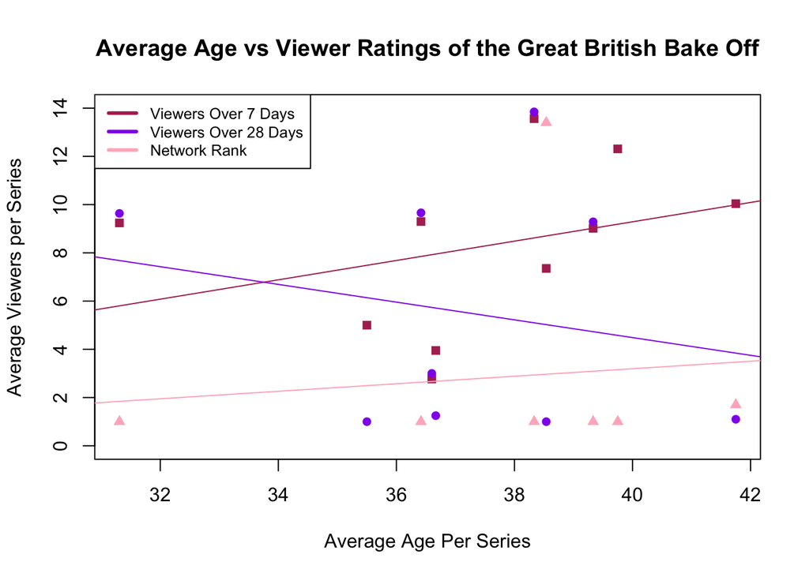

```r
gbb_scatter <- plot(gbb$`average age`, gbb$viewers_7day, pch = 15, col = "maroon", ylim = c(0,14), xlab = "Average Age Per Series", ylab = "Average Viewers per Series")
    abline(lm(gbb$viewers_7day ~ gbb$`average age`), col = "maroon")
  points(gbb$`average age`, gbb$viewers_28day, pch = 16, col = "purple2")
    abline(lm(gbb$viewers_28day ~ gbb$`average age`), col="purple2")
  points(gbb$`average age`, gbb$network_rank, pch = 17, col = "pink1")
    abline(lm(gbb$network_rank ~ gbb$`average age`), col= "pink1")
  title("Average Age vs Viewer Ratings of the Great British Bake Off")
  legend("topleft", cex = .8,
         legend = c("Viewers Over 7 Days", "Viewers Over 28 Days", "Network Rank"),
         lwd = 3, col = c("maroon", "purple2", "pink1"))
```

From the graph, it can be clearly seen that there is no correlation between the average age of the contestants on the show and the viewership. Not only are most of the the points seemingly random, with no strong correlation, the lines of correlation have conflicting slopes, suggesting no relationship between the independent and dependent variables.

## Graph Type Two: Bar Plot

I created two bar plots, one to represent the ratings and one to represent the ages of the bakers. I began with the bar plot to represent the ratings data. First, I used the par(mfrow =) function to put the two bar plots side by side (I could not use grid.arrage( ) because the barplot( ) is not a ggplot2 function). I created a variable called “ratingsbyseries” using the group_by( ) function to group the ratings data by series. I then used the as_tibble( ) function to force it into a tibble, used the summarize( ) function to get all of the data that I needed into the tibble, and then in order to put the information into the bar plot, I had to make it into a matrix. For aesthetic purposes, I used colorRampPalette to create a gradient of colors from “azure2” to “navyblue”, calling it “seriescolors” and I tested it by typing seriescolors(10), which would give ten colors including and between the two of the desired gradient. To create the actual bar plot, I created the variable “gbb_bar1”, assigning it to be barplot( ) with the x-value being the “ratingsseries”, having the bars beside each other (represented by “beside = TRUE”), creating a legend (using “legend = TRUE”), creating a label for the y-axis, making my gradient I made earlier the colors of the bars, and I used “cex.names =” to change the size of the text for the label of the y-axis. I then added the text for the legend and the corresponding colors as well as a title, using “cex.man =” to change the size of the text of the title. I used a similar technique to create the second bar plot, representing age.

```r
# to put the two plots side by side
  par(mfrow = c(1:2))
# the first bar plot : ratings
ratingsbyseries <- group_by(ratings, series)
ratingsbyseries <- as_tibble(ratingsbyseries)
ratingsbyseries <- summarize(ratingsbyseries, viewers_7day, viewers_28day, network_rank)
ratingsbyseries <- as.matrix(ratingsbyseries)

seriescolors <- colorRampPalette(c("azure2", "navyblue"))
seriescolors(10)
```

```
##  [1] "#E0EEEE" "#C7D3E1" "#AEB9D5" "#959EC9" "#7C84BD" "#6369B0" "#4A4FA4"
##  [8] "#313498" "#181A8C" "#000080"
```

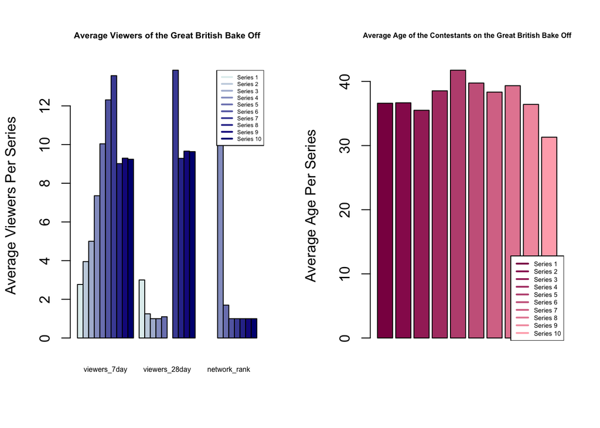

```r
gbb_bar1 <- barplot(ratingsbyseries, beside = TRUE, legend = TRUE, ylab = "Average Viewers Per Series", col = seriescolors(10), cex.names = .5)
  legend("topright", cex = .4,
         legend = c("Series 1", "Series 2","Series 3","Series 4","Series 5","Series 6","Series 7","Series 8","Series 9","Series 10"),
         lwd = 2, col = seriescolors(10))
  title("Average Viewers of the Great British Bake Off", cex.main = .6)
# the second bar plot : ages
agebyseries <- group_by(bakers, series)
agebyseries <- as_tibble(agebyseries)
agebyseries <- as.matrix(agebyseries)
agebyseries <- agebyseries[,-1]

agecolors <- colorRampPalette(c("deeppink4", "lightpink1"))

gbb_bar2 <- barplot(agebyseries, beside = TRUE, legend = TRUE, ylab = "Average Age Per Series", col = agecolors(10), cex.names = .6)
  legend("bottomright", inset(-.02, -.03), cex = .45,
       legend = c("Series 1", "Series 2","Series 3","Series 4","Series 5","Series 6","Series 7","Series 8","Series 9","Series 10"),
       lwd = 2, col = agecolors(10))
  title("Average Age of the Contestants on the Great British Bake Off", cex.main = .5)
```

When comparing the plots, the observers can see that there is no correlation between the viewers of the show and the age of the contestants. The two bar plots do not follow the same pattern of increasing or decreasing as series increase or decrease, implying that there is no relationship between the amount in viewers of the Great British Bake Off and the average age of the contestants.

## Graph Type Three: Pairwise Scatter Plot

The final type of graph that I chose to use in my analysis was a pairwise scatter plot, once again because I felt that it could easily and elegantly show the relationship between the ratings and age of the bakers. I then created a new variable called “gbb_pairs” which contains both the bakers’ average ages and ratings information, without the series information using the select( ) function, keeping only the variables that I have previously stated. I also created a variable called “pairscolors” and assinged it to the gradient of colors between “plum” and “darkorchid4” using colorRampPalette. I then used this data and replaced the variable gbb_pairs as the pairwise scatter plot of the data using the pairs( ) function. For aesthetic purposes, I used “col =” to assign the gradient I previously created to the colors of the graph and I created a title.

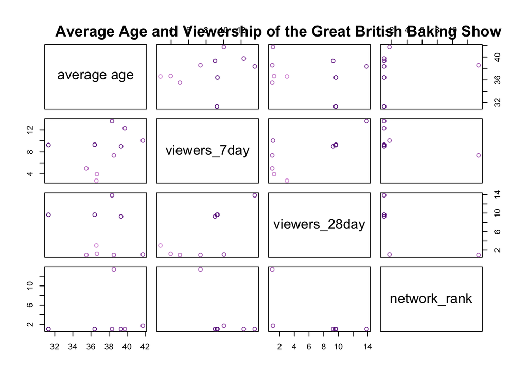

```r
gbb_pairs <- gbb %>%
  select(`average age`, viewers_7day, viewers_28day, network_rank)
pairscolors <- colorRampPalette(c("plum", "darkorchid4"))

gbb_pairs <- pairs(gbb_pairs, col = pairscolors(10))
  title("Average Age and Viewership of the Great British Baking Show")
```

# Summary

In my analysis, I wanted to explore the relationship between the average age of the contestants on the Great British Bake Off and the amount of ratings of the show. The data that I used ranged from the first 10 series/season of the show, from 2010 to 2019. Prior to beginning my examination of the data, I thought that there may have been a change in viewership based on age because different populations were being represented in the show, and therefore different people were gaining and losing interest based on who they saw on screen. However, upon inquiry into the statistics, I found that there is no correlation between the average age of contestants on the Great British Bake Off and the amount of viewers and ratings based off of the first ten series.

# Resources

- https://github.com/rfordatascience/tidytuesday/tree/master/data/2022/2022-10-25#great-british-bakeoff
- https://thegreatbritishbakeoff.co.uk/about-the-show/
- https://en.wikipedia.org/wiki/The_Great_British_Bake_Off